# Figures for PRIMM PhIP-Seq paper

Plots created with phiper package

Magdalena Hübner

2026-04-21

# 1 Metadata

I noticed that there is one sample (**LV1016273557**) which has two metadata entries belonging to two completely different patients.

```
##        LV_code patientid timepoint     centre age Sample.ID response
## 1 LV1016273557   OL_3049        T0 UMCG_PRIMM  63  PRIMM184        R
## 2 LV1016273557   MVCC011        T2  KCL_PRIMM  86  PRIMM184       NR
```

```
##        LV_code patientid timepoint    centre age Sample.ID response
## 1 LV1016273557   MVCC011        T2 KCL_PRIMM  86  PRIMM184       NR
## 2 LV1016273550   MVCC011        T1 KCL_PRIMM  86  PRIMM111       NR
## 3 LV1016274961   MVCC011        T0 KCL_PRIMM  86  PRIMM082       NR
```

```
##        LV_code patientid timepoint     centre age Sample.ID response
## 1 LV1016273557   OL_3049        T0 UMCG_PRIMM  63  PRIMM184        R
```

My suspicion is that the sample belongs to OL_3049 (T0). Because otherwise if it belonged to MVCC011 (T2) this sample should correlate with MVCC011 (T0 & T1) which is doesn’t:

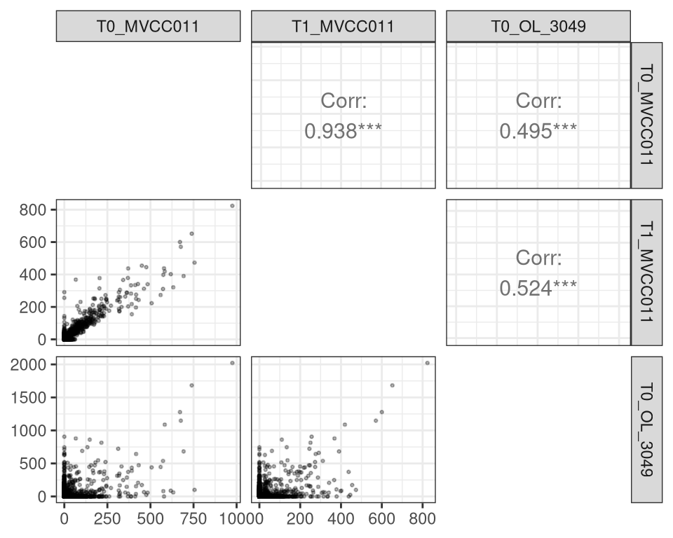

Initially I removed this sample from the analysis. This is how the plots for Johannes grant were generated.

# 2 Figure 1

## 2.1 Alpha Diversity

- Richness: The absolute number of antibody-bound peptides/taxa rank per individual between groups.
- Shannon: A given taxonomic rank diversity of Ig repertoires of antibody-bound peptides per individual between groups.

**This was done with phiper**

We could consider using a richness cutoff (e.g. 200)?

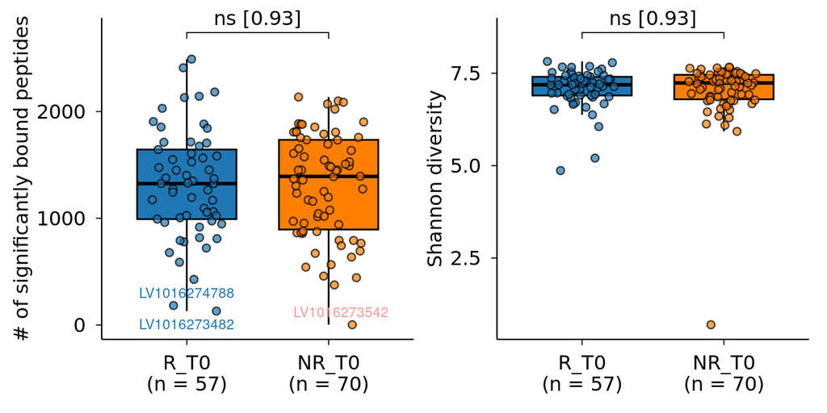

## 2.2 Beta Diversity

- For each peptide Bray–Curtis dissimilarity is computed on the binary abundance taxonomic matrix and carried out a Principal Coordinates Analysis (PCoA/MDS).
- On the scatterplot, each point is a sample and the 95% confidence ellipses show the group clustering.
- Tested for overall differences in community composition between groups with PERMANOVA, reporting the p-value in the plot. To check that any PERMANOVA result wasn’t driven by unequal dispersion, a permutation test on the multivariate dispersions was run.
- Together, these panels tell you whether (a) the two groups occupy distinct regions of Bray–Curtis space (significant PERMANOVA) and (b) whether one group is more dispersed than the other (significant dispersion test).

**This was done with phiper**

I can see 2 clusters at TP1, is this an experimental batch effect? –> Probably CMV

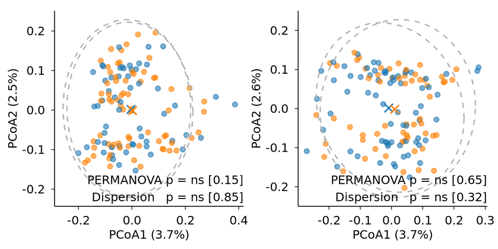

## 2.3 Heatmap

### 2.3.1 R_T0_vs_R_T1

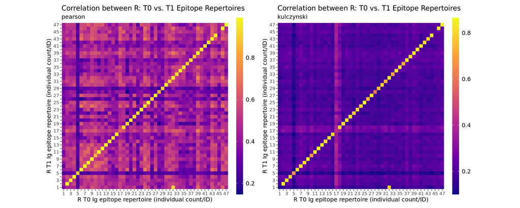

### 2.3.2 NR_T0_vs_NR_T1

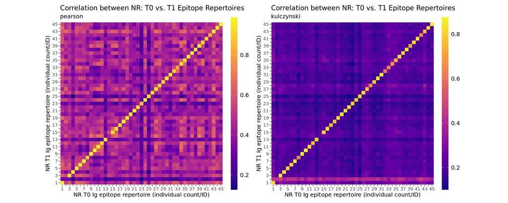

### 2.3.3 Pearson (T0/T1) - R and NR combined

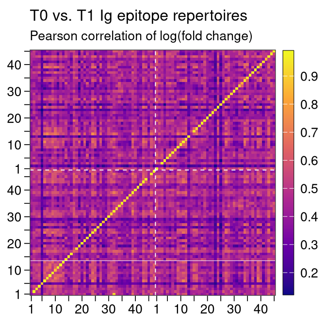

## 2.4 Heatmap - Outlier

I wanted to investigate the outlier in the responder heatmap because it doesn’t make sense to me. First I thought maybe those two samples both have a very low number of enriched peptides, but that’s not the case. Then I thought maybe the sample labels were swapped, but then the correlation should be symmetric. I now have the suspicion that patient 23 (T1) wasn’t measured and is actually a sample from patient PBT313 that was measured twice?

- Patient 23 (T0) doesn’t correlate with anything
- For patient PBT313 timepoints correlate with each other
- And they both correlate with patient 23 (T1)

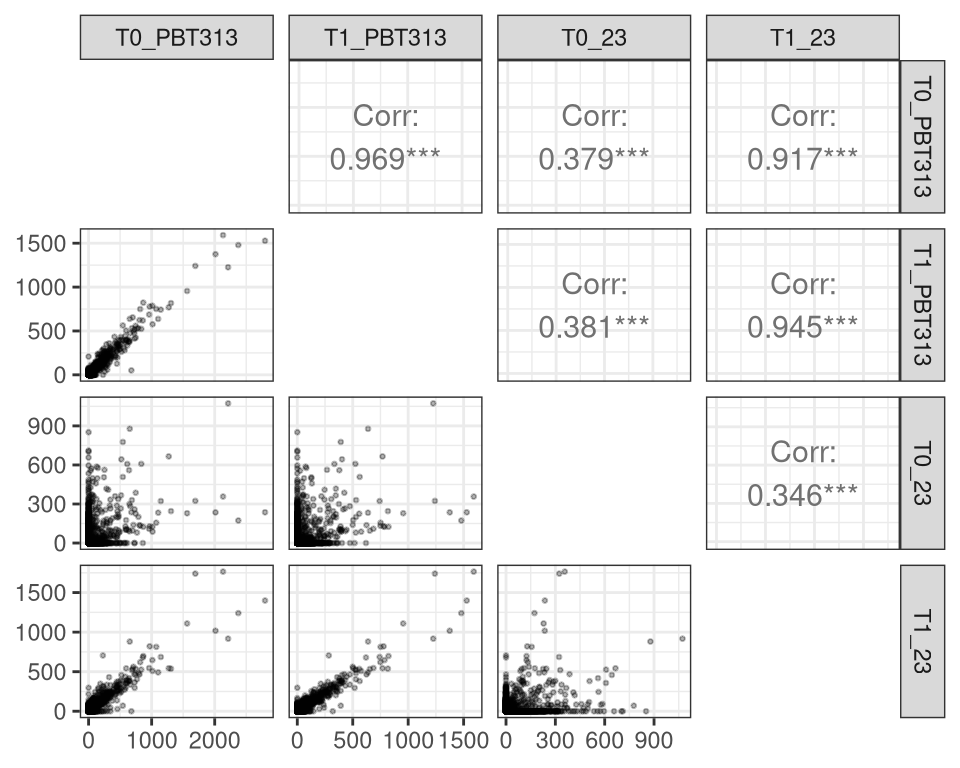

## 2.5 Correlation coefficients (Histogram)

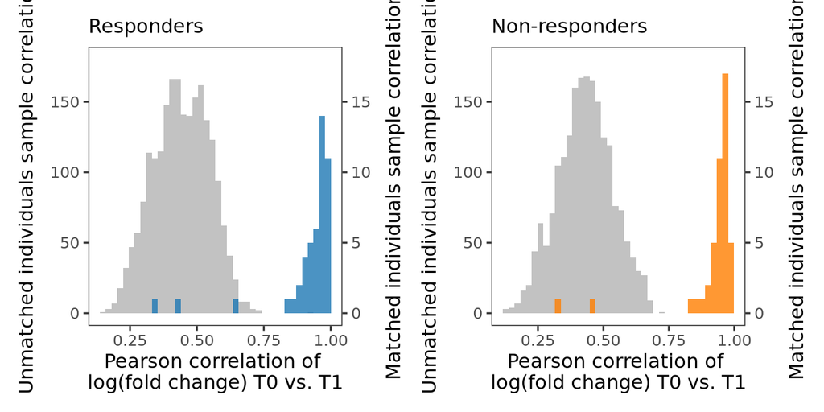

## 2.6 Correlation coefficients (Barplots)

- Do we want statistical significance here? They are all non-significant.
- Add the number of samples that were considered in each comparison?

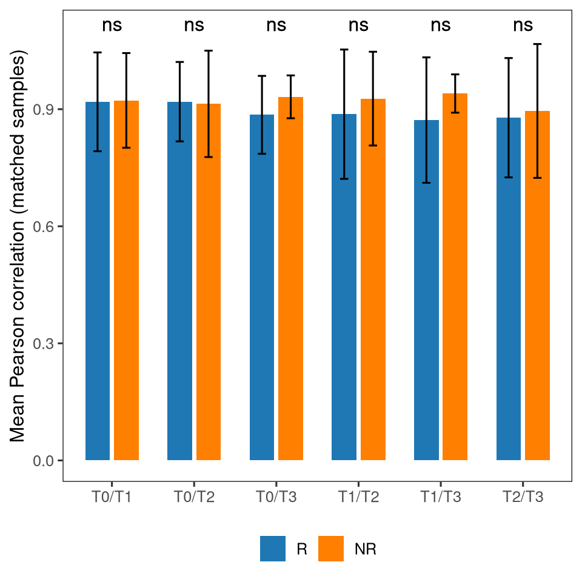

# 3 Significant Taxa / Annotations

## 3.1 POP framework

| rank | feature | p_raw | p_adj_rank | percent1 | percent2 | group1 | group2 | n_peptides | group_col | n1 | N1 | prop1 | n2 | N2 | prop2 | passed_rank_bh | category_rank_bh | p_adj_rank_wbh | passed_rank_wbh | category_rank_wbh |
| --- | --- | --- | --- | --- | --- | --- | --- | --- | --- | --- | --- | --- | --- | --- | --- | --- | --- | --- | --- | --- |
| class | Malacostraca | 0.005647108 | 0.3081621 | 42.10526 | 18.571429 | R_T0 | NR_T0 | 41 | group_char | 24 | 57 | 0.4210526 | 13 | 70 | 0.18571429 | FALSE | nominal only | 1 | FALSE | nominal only |
| class | Pichiomycetes | 0.008804630 | 0.3081621 | 26.31579 | 8.571429 | R_T0 | NR_T0 | 29 | group_char | 15 | 57 | 0.2631579 | 6 | 70 | 0.08571429 | FALSE | nominal only | 1 | FALSE | nominal only |
| class | Coriobacteriia | 0.025870872 | 0.6036537 | 80.70175 | 94.285714 | R_T0 | NR_T0 | 94 | group_char | 46 | 57 | 0.8070175 | 66 | 70 | 0.94285714 | FALSE | nominal only | 1 | FALSE | nominal only |
| order | Decapoda | 0.005647108 | 0.7087727 | 42.10526 | 18.571429 | R_T0 | NR_T0 | 40 | group_char | 24 | 57 | 0.4210526 | 13 | 70 | 0.18571429 | FALSE | nominal only | 1 | FALSE | nominal only |
| order | Serinales | 0.008804630 | 0.7087727 | 26.31579 | 8.571429 | R_T0 | NR_T0 | 26 | group_char | 15 | 57 | 0.2631579 | 6 | 70 | 0.08571429 | FALSE | nominal only | 1 | FALSE | nominal only |
| order | Acetobacterales | 0.016469641 | 0.8838707 | 8.77193 | 0.000000 | R_T0 | NR_T0 | 6 | group_char | 5 | 57 | 0.0877193 | 0 | 70 | 0.00000000 | FALSE | nominal only | 1 | FALSE | nominal only |
| species | Bifidobacterium dentium | 0.001343220 | 1.0000000 | 21.05263 | 2.857143 | R_T0 | NR_T0 | 9 | group_char | 12 | 57 | 0.2105263 | 2 | 70 | 0.02857143 | FALSE | nominal only | 1 | FALSE | nominal only |
| species | Helicobacter acinonychis | 0.002958778 | 1.0000000 | 12.28070 | 0.000000 | R_T0 | NR_T0 | 10 | group_char | 7 | 57 | 0.1228070 | 0 | 70 | 0.00000000 | FALSE | nominal only | 1 | FALSE | nominal only |
| species | Bacteroides intestinalis | 0.008276042 | 1.0000000 | 0.00000 | 11.428571 | R_T0 | NR_T0 | 12 | group_char | 0 | 57 | 0.0000000 | 8 | 70 | 0.11428571 | FALSE | nominal only | 1 | FALSE | nominal only |
| family | Debaryomycetaceae | 0.008804630 | 1.0000000 | 26.31579 | 8.571429 | R_T0 | NR_T0 | 26 | group_char | 15 | 57 | 0.2631579 | 6 | 70 | 0.08571429 | FALSE | nominal only | 1 | FALSE | nominal only |

## 3.2 DELTA framework

| rank | feature | p_adj_rank | p_perm | Z_from_p | group_col | group1 | group2 | design | n_subjects_paired | n_peptides_used | m_eff | T_obs | T_obs_stand | b | max_delta | frac_delta_pos | frac_delta_pos_w | fold_change_sum | cross_prev_mean | category_rank_bh |
| --- | --- | --- | --- | --- | --- | --- | --- | --- | --- | --- | --- | --- | --- | --- | --- | --- | --- | --- | --- | --- |
| is_bac_flagella | 1 | 0.02396651 | 0.023966507 | -2.257666 | group_char | R_T0 | NR_T0 | unpaired | NA | 562 | 431.476953 | -7.794321 | -2.299404 | 3594 | 0.25582807 | 0.4021352 | 0.34440467 | 133671.8053 | 0.03725446 | significant (BH, per rank) |
| is_EBV | 1 | 0.02778648 | 0.027786481 | -2.200288 | group_char | R_T0 | NR_T0 | unpaired | NA | 46 | 35.671272 | -6.872505 | -2.191764 | 4167 | 0.17350656 | 0.1304348 | 0.10211297 | 350043.2670 | 0.31239302 | significant (BH, per rank) |
| class | Malacostraca | 0.71306191 | 0.013873241 | -2.460529 | group_char | R_T0 | NR_T0 | unpaired | NA | 16 | 13.410967 | -4.120471 | -2.464233 | 2080 | 0.11765420 | 0.0625000 | 0.03684322 | 5165.1216 | 0.04625984 | nominal only |
| class | Conoidasida | 0.71306191 | 0.026413157 | 2.220083 | group_char | R_T0 | NR_T0 | unpaired | NA | 12 | 11.099848 | 2.799853 | 2.174661 | 3961 | 0.11109762 | 0.7500000 | 0.76778755 | 2145.7462 | 0.02887139 | nominal only |
| class | Aves | 0.71306191 | 0.030559796 | 2.162758 | group_char | R_T0 | NR_T0 | unpaired | NA | 40 | 33.133978 | 4.549154 | 2.158404 | 4583 | 0.15165129 | 0.8000000 | 0.85244918 | 10186.7344 | 0.04035433 | nominal only |
| species | Bifidobacterium dentium | 1.00000000 | 0.001193325 | -3.240471 | group_char | R_T0 | NR_T0 | unpaired | NA | 4 | 3.633163 | -3.139962 | -3.271439 | 178 | 0.09409908 | 0.0000000 | 0.00000000 | 900.8250 | 0.02952756 | nominal only |
| species | Helicobacter acinonychis | 1.00000000 | 0.002906647 | -2.977442 | group_char | R_T0 | NR_T0 | unpaired | NA | 5 | 4.949557 | -2.466646 | -3.152212 | 435 | 0.03606119 | 0.0000000 | 0.00000000 | 179.3811 | 0.01102362 | nominal only |
| genus | Paraprevotella | 1.00000000 | 0.006753288 | 2.708771 | group_char | R_T0 | NR_T0 | unpaired | NA | 21 | 10.397164 | 3.011041 | 2.715306 | 1012 | 0.15529383 | 0.6666667 | 0.69862806 | 37794.1584 | 0.11248594 | nominal only |
| genus | Atopobium | 1.00000000 | 0.010706595 | 2.552132 | group_char | R_T0 | NR_T0 | unpaired | NA | 4 | 1.918316 | 2.479876 | 2.564302 | 1605 | 0.18831957 | 0.7500000 | 0.90041134 | 22378.8596 | 0.19881890 | nominal only |
| family | Atopobiaceae | 1.00000000 | 0.011186592 | 2.536815 | group_char | R_T0 | NR_T0 | unpaired | NA | 4 | 1.918316 | 2.479876 | 2.555034 | 1677 | 0.18831957 | 0.7500000 | 0.90041134 | 22378.8596 | 0.19881890 | nominal only |

# 4 Figure 2

## 4.1 Peptide Comparison Between Groups (POP)

### 4.1.1 R_T0_vs_NR_T0

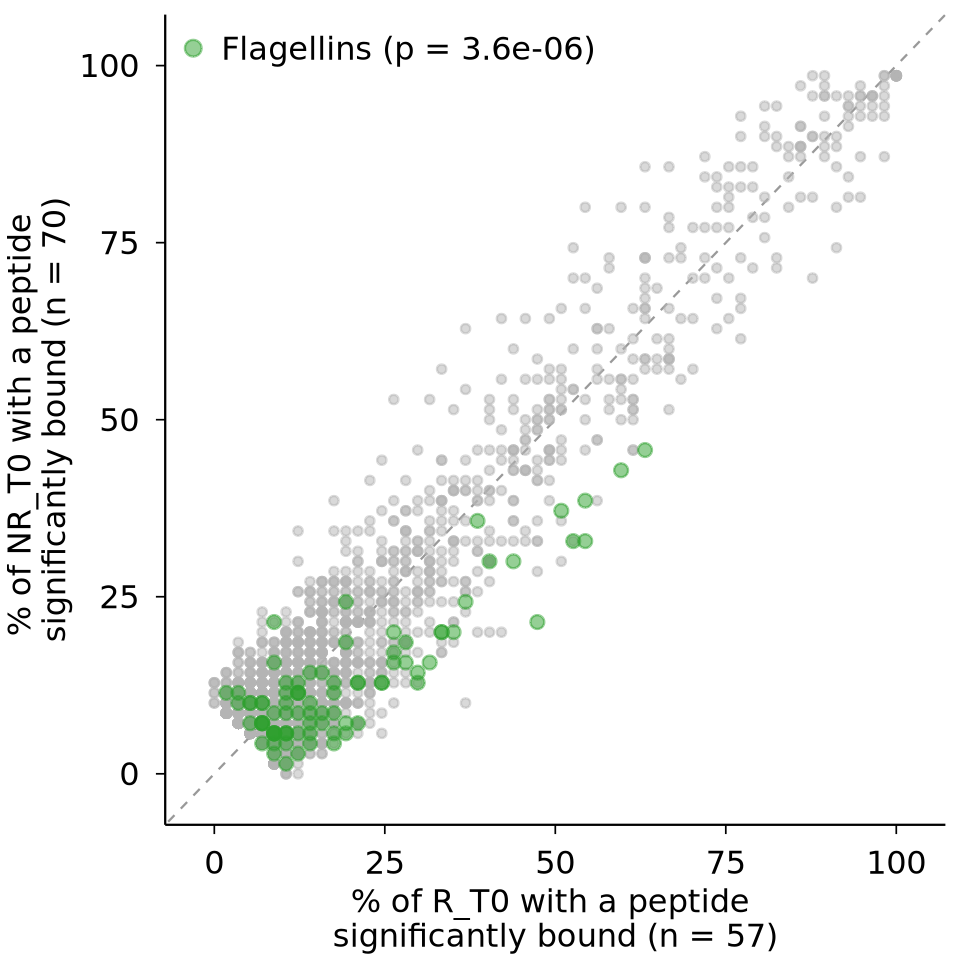

### 4.1.2 R_T1_vs_NR_T1

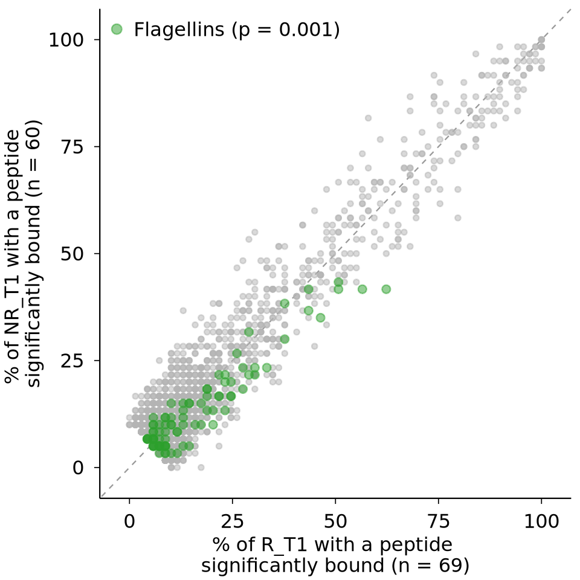

### 4.1.3 R_T0_vs_R_T1

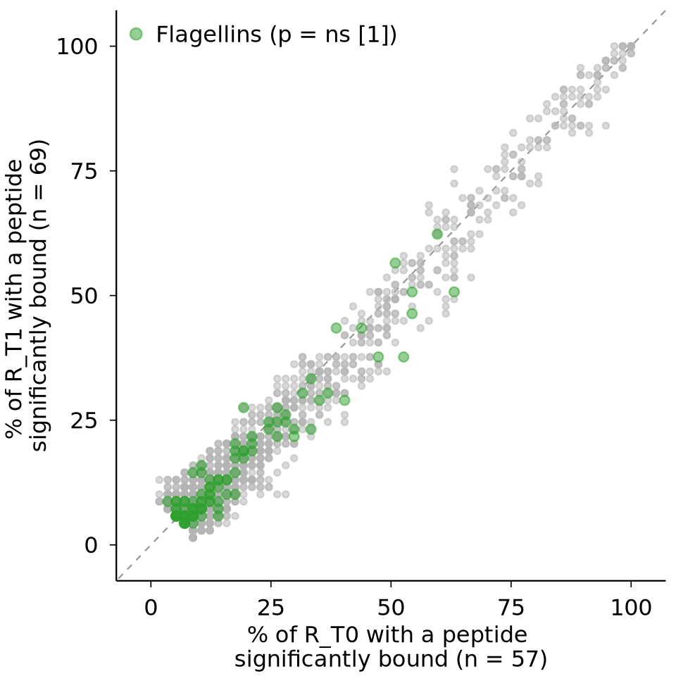

### 4.1.4 NR_T0_vs_NR_T1

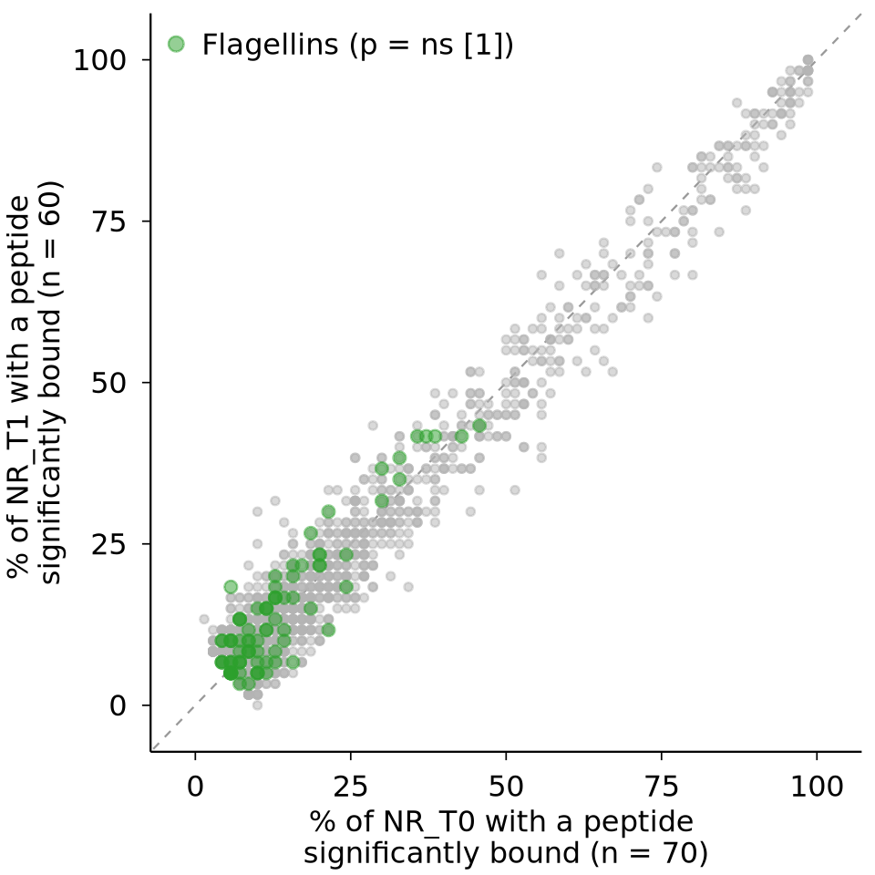

## 4.2 Ratios of response by oligo family

- I set an arbitrary prevalence threshold of at least prop1 + prop2 >= 0.1
- For some of the library categories not sure if they are correct?
- Significance calulated with Wilcoxon and Bonferroni corrected
- Can’t seem to reproduce the same plot. What test?
- How are ratios calculated (to avoid Inf)?

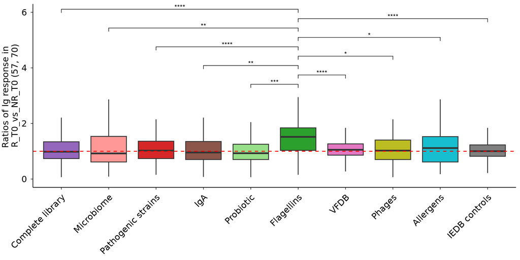

## 4.3 Ratios of response to flagellins by class at different timepoints

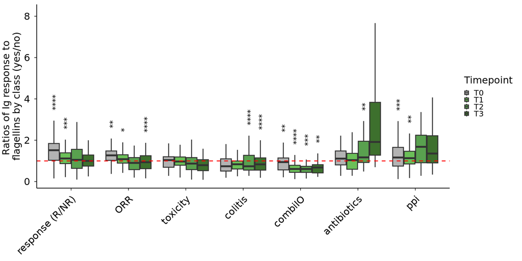

# 5 Additional Plots

- Here the dates are way more extreme than in the original figure. Why?
- Used serum_collection_date-start_io (weeks)

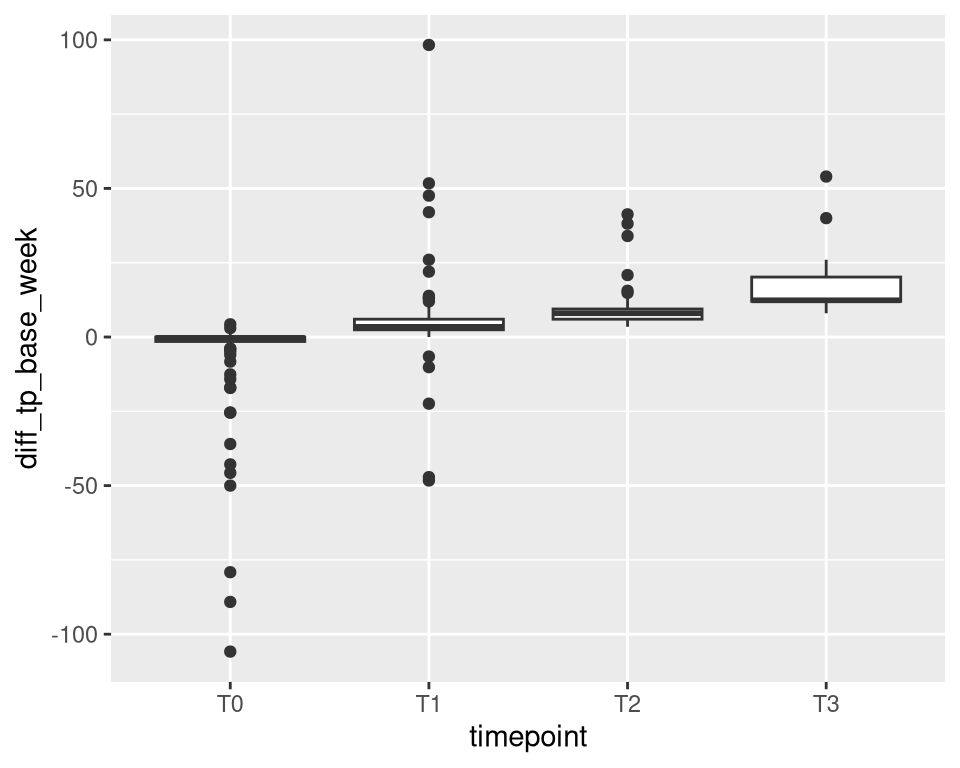

# 6 Survival analysis

The survival data only has sample IDs (stool samples), no patient IDs. However, I was able to uniquely match patients based on age, sex and BMI.

```
## [1] "Patients with PhIP-Seq data (T1):"
```

```
## [1] 129
```

```
## [1] "Patients with PhIP-Seq data (T1) and survival data (initial metadata):"
```

```
## [1] 74
```

```
## [1] "Patients with PhIP-Seq data (T1) and survival data (new metadata):"
```

```
## [1] 76
```

```
## [1] 90
```

```
##
## NR  R
## 40 50
```

```
##
##   KCL_PRIMM        LEED UMCG_COLIPI  UMCG_PRIMM
##          36          16           9          29
```